# Poisson test

2020-05-27

Busco jugar un poco con 2 distintos tests de Poisson para diferencias entre medias, explicados en el paper [A more powerful test for comparing two Poisson means](https://userweb.ucs.louisiana.edu/~kxk4695/JSPI-04.pdf), de K. Krishnamoorthy y Jessica Thomson.

# Reproducción manual de las posibles formas de realizar el test

Carga de dependencias:

```r
library("data.table")
library('tidyverse')
```

Antes que nada, seteo algunos parámetros de ejemplo:

```r
set.seed(999)
alpha <- 0.05
n1 <- 10
n2 <- 15
lambda1 <- 6
lambda2 <- 4
```

Simulo un par de muestras:

```r
muestra1 <- rpois(n1, lambda1)
muestra2 <- rpois(n2, lambda2)
```

## Usando el paquete ‘stats’ de R

```r
k1 <- sum(muestra1) # Valores observados de una Poisson(n1 * lambda1)
k2 <- sum(muestra2) # Valores observados de una Poisson(n2 * lambda2)
k <- k1 + k2
```

Resultado de la función estandar de R:

```r
poisson.test(c(k1, k2), c(n1, n2), alternative = 'greater')
```

```
##
##  Comparison of Poisson rates
##
## data:  c(k1, k2) time base: c(n1, n2)
## count1 = 56, expected count1 = 46.8, p-value = 0.0512
## alternative hypothesis: true rate ratio is greater than 1
## 95 percent confidence interval:
##  0.9978543       Inf
## sample estimates:
## rate ratio
##   1.377049
```

```r
#poisson.test(c(850, 780), c(1, 1), alternative = 'greater')
```

## Implementación manual del C-test

Planteo hipótesis nulas de la forma:

H0: lambda1 / lambda2 <= c, o bien

H0: lambda1 - lambda2 <= d

(X1|X1+X2=k) ~ Binomial(n = k, p = lambda1 / (lambda1 + lambda 2)),

O si n1 != n2, p = (n1/n2)*(lambda1/lambda2) / (1 + (n1/n2)*(lambda1/lambda2))

```r
p_cociente <- function(n1, n2, cociente)  (n1/n2)*(cociente) / (1 + (n1/n2)*(cociente))
```

Bajo la Hipótesis nula de que el cociente sea igual a c (por ejemplo c = 1, para lambda1=lambda2):

```r
c <- 1
d <- 0
p <- p_cociente(n1, n2, c)
```

Dado que bajo la hipótesis nula y los k casos totales observados, X1 sigue una distribución binomial que conocemos, podemos calcular el p-valor (la probabilidad de que X1 tome un valor tanto o más extremo que el valor observado k1) como la suma de las probabilidades puntuales para todos los valores entre k1 y k:

```r
comb <- function(n, k) factorial(n) / factorial(n-k) / factorial(k) #Función combinatoria
sumando <- function(p, k, i) comb(k, i) * p^i * (1 - p)^(k - i) #Términos de la sumatoria
pvalor <- function(k1, k) {
  seq(k1, k, 1) %>%
  lapply(function(i) sumando(p, k, i)) %>%
  unlist() %>%
  sum()
}
pvalor(k1, k)
```

```
## [1] 0.05119745
```

Observamos entonces que el p-valor así calculado es idéntico al que había arrojado la función poisson.test.

**Alternativamente**, en vez de calcular el p-valor, puedo ir calculando la suma cumulativa de probabilidades puntuales, de modo que al llegar a *1 - alpha* habré encontrado el valor crítico del test.

```r
x1_posibles <- seq(0, k)
probs_acumuladas <- cumsum(sumando(p, k, x1_posibles))
crit_val <- x1_posibles[probs_acumuladas > (1 - alpha)][1]
# Rechazo H0 sii k1 > crit_val
crit_val
```

```
## [1] 56
```

De este modo se obtiene el valor crítico `56`, que tal vez podría ser utilizado para un eventual análisis de potencia (bajo el supuesto de que el total de casos sea igual a k). Dado que k1 tiene un valor de `56`, decido no rechazar; lo que está en consonancia con el p-valor obtenido.

## Implementación manual del E-test

### Cálculos preliminares

#### Validación empírica de la varianza de la diferencia

```r
nsims <- 10000
sims <- rep(0, nsims)
for (i in 1:nsims) {
  n1_sim <- 1000
  n2_sim <- 100
  X1_sim <- rpois(n1, lambda1) %>% sum()
  X2_sim <- rpois(n2, lambda2) %>% sum()

  diff <- X1_sim / n1_sim - X2_sim / n2_sim
  sims[i] <- diff
}
var(sims)
```

```
## [1] 0.006001844
```

```r
lambda1/n1 + lambda2/n2
```

```
## [1] 0.8666667
```

### Implementación del E-test

#### Implementación tomando una malla arbitraria de valores en (X1, X2)

Estimador de la varianza de la diferencia entre X1 y X2:

```r
var_hat <- function(x1, x2, n1, n2) x1 / n1^2 + x2 / n2^2
```

Se usa la diferencia estandarizada como estadístico pivot, donde *d* es la diferencia pautada por la Hipótesis Nula (comunmente 0):

```r
T_x1_x2 <- function(x1, x2, n1, n2, d) {
  if (x1 == 0 && x2 == 0) {
    if (d == 0) T <- 0 else T <- -Inf
  } else {
    return((x1 / n1 - x2 / n2 - d) / sqrt(var_hat(x1, x2, n1, n2)))
  }
  return(T)
}
```

Dadas las muestras (k1, k2, n1, n2) obtenidas, el valor observado para el estadístico T es:

```r
T_k1_k2 <- T_x1_x2(k1, k2, n1, n2, d)
```

Bajo la hipótesis nula, lambda1 = lambda2 + d; lo que lleva al siguiente estimador de lambda2:

```r
lambda2k_hat <- (k1 + k2) / (n1 + n2) - d * n1 / (n1 + n2)
```

Si lambda2 da negativo, no se rechaza, dado que mi mejor estimación de lambda2 está dando más grande que lambda1 + d:

```r
if (lambda2k_hat <= 0) {
  reject <- FALSE
  break
}
```

Para una Poisson(lambda), la función de probabilidad puntual es:

```r
p_puntual_poisson <- function(x, lambda) dpois(x, lambda) #exp(-lambda) * lambda^x / factorial(x)
```

Luego, para el vector (X1, X2) bajo la H0 y con lambda2 estimado por lambda2k_hat, la función de probabilidad puntual es:

```r
p_puntual_x1_x2 <- function(x1, x2) p_puntual_poisson(x2, n2 * lambda2k_hat) * p_puntual_poisson(x1, n1 * (lambda2k_hat + d))
```

El p-valor de nuestro test es la posibilidad de haber observado un valor `T_x1_x2` tan o más extremo que `T_k1_k2` bajo la H0. Y esto puede ser calculado exactamente como la suma de las probabilidades puntuales `p_puntual_x1_x2` en los casos en que `T_k1_k2 >= T_k1_k2`. El cálculo exacto del p-valor implicaría una suma infinita, dado que teóricamente x1 y x2 pueden tomar el valor de cualquier entero positivo. No obstante dado que lo único que nos interesa es saber si el p-valor está por debajo del nivel de significancia *alpha*, podemos dejar de sumar una vez que tengamos certeza sobre si esto será así; ya sea porque la suma del p-valor excedió *alpha*, o porque la suma sobre `T_k1_k2 < T_k1_k2` excedió *1-alpha*.

Dado que esta no pretende ser la implementación final del E-test, no se tendrán consideraciones como buscar dinámicamente los x1, x2 en los que dejar de sumar, ni aprovechar la recursividad de P(X = j+1) = P(X = j) * lambda / (j+1) para hacer más eficientes las cuentas.

En vez de ello, tomamos “a ojo” un rango suficientemente grande y calculamos las probabilidades puntuales correspondientes.

```r
expand.grid.df <- function(...) Reduce(function(...) merge(..., by=NULL), list(...))
x1_max <- 2 * ceiling(n1 * (lambda2k_hat + d))
x2_max <- 2 * ceiling(n2 * lambda2k_hat)
grid_x1_x2 <- expand.grid.df(1:x1_max, 1:x2_max) %>% setnames(c('x1', 'x2'))
probs <- map2_dbl(grid_x1_x2$x1, grid_x1_x2$x2, p_puntual_x1_x2)
estadisticoT <- map2_dbl(grid_x1_x2$x1, grid_x1_x2$x2, function(x1, x2) T_x1_x2(x1, x2, n1, n2, d))
indicadora <- estadisticoT >= T_k1_k2

sum(probs)
```

```
## [1] 1
```

Observemos que considerar estos valores de (x1, x2) barre con casi la totalidad de la probabilidad acumulable, dejando por fuera una cola de tan solo `4.1761383\times 10^{-10}`, lo cual sería relevante sólo en casos límite.

```r
sumandos_consolidados <- data.table(grid_x1_x2, probs, estadisticoT, indicadora)
sumandos_consolidados[, .(suma_probabilidades = sum(probs)), indicadora]
```

```
##    indicadora suma_probabilidades
## 1:      FALSE          0.95722837
## 2:       TRUE          0.04277163
```

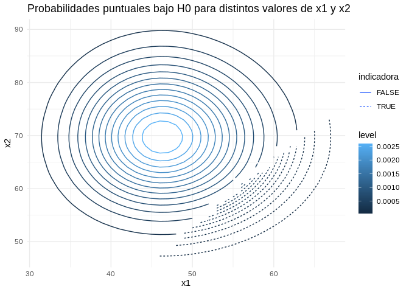

```r
sumandos_consolidados %>%
  ggplot() +
  geom_contour(aes(x1, x2, z = probs, colour = ..level.., linetype = indicadora)) +
  theme_minimal() +
  ggtitle("Probabilidades puntuales bajo H0 para distintos valores de x1 y x2")
```

En este ejemplo, observamos que la suma de las probabilidades puntuales supera el umbral de 0.95. Por lo tanto, podemos estar seguros de que el p-valor estará por debajo de 0.05, y por lo tanto rechazamos la hipótesis nula.

Es interesante notar que el E-test logra rechazar la Hipótesis Nula, mientras que el C-test no lo había hecho, al haber llegado a un p-valor de `0.0511974`. Esto está en consonancia con la afirmación respecto a mayor potencia por parte de Krishnamoorthy y Thomson.

#### Implementación iterando sobre la distancia a la moda hasta obtener una estimación del p-valor suficiente

```r
param_poisson1 <- n1 * (lambda2k_hat + d)
param_poisson2 <- n2 * lambda2k_hat

moda1 <- floor(param_poisson1)
moda2 <- floor(param_poisson2)
```

Distintas funciones para devolver una tabla con todos los puntos (x1, x2) a una cierta distancia de un punto central:

```r
calcula_puntos_a_distancia_de_moda <- function(dist_moda, moda1, moda2) {
  if (dist_moda == 0) {
    x1 <- 0
    x2 <- 0
  } else {
    x1 <- c(seq(-dist_moda, 0), seq_len(dist_moda), rev(-seq_len(dist_moda-1)), 0, seq_len(dist_moda-1))
    x2 <- c(seq(0, dist_moda), rev(seq_len(dist_moda-1)), -seq(0, dist_moda), -rev(seq_len(dist_moda-1)))
    }
  data.table(x1 = x1 + moda1, x2 = x2 + moda2)
}
calcula_puntos_a_distancia_de_moda2 <- function(dist_moda, moda1, moda2) {
  grid_x1_x2 <- expand.grid.df(seq(moda1 - dist_moda, moda1 + dist_moda),
                               seq(moda2 - dist_moda, moda2 + dist_moda)) %>%
    setnames(c('x1', 'x2')) %>%
    setDT()
  grid_x1_x2 %>%
    .[abs(x1 - moda1) + abs(x2 - moda2) == dist_moda]
}
calcula_puntos_a_distancia_de_moda3 <- function(dist_moda, moda1, moda2) {
  points_list <- list()
  points_dt <- data.table()
  if (dist_moda > 1) {
    for(i in seq_len(dist_moda - 1)) {
      points_list <- list(data.table(i,  dist_moda - i),
                          data.table(i, -dist_moda + i)) %>%
        c(points_list)
    }
    points_dt_partial <- rbindlist(points_list) %>% setnames(c('x1', 'x2'))
    points_dt <- points_dt_partial %>%
      copy() %>%
      .[, x1 := -x1] %>% #crea puntos espejados respecto del eje y
      rbind(points_dt_partial)
  }
  points_dt <- data.table(x1 = c(dist_moda, -dist_moda, 0, 0), #agrega vértices del rombo
                          x2 = c(0, 0, dist_moda, -dist_moda)) %>%
    unique() %>%
    rbind(points_dt)
  #Centra rombo en los los puntos de mayor probabilidad:
  points_dt[, x1 := x1 + moda1]
  points_dt[, x2 := x2 + moda2]
  #points_dt <- points_dt[x1 > n1 * d]
  #points_dt <- points_dt[x2 < x1 * n2 / n1]
  return(points_dt)
}
```

Funciones que usan la fórmula recursiva para agregar a una tabla las probabilidades anteriores y posteriores:

```r
add_next_prob <- function(prob_table, param_poisson) {
  max_value <- max(prob_table[, x])
  rbind(prob_table,
        data.table(x = max_value + 1,
                   p = param_poisson / (max_value + 1) * prob_table[x == max_value, p]))
}
add_previous_prob <- function(prob_table, param_poisson) {
  min_value <- min(prob_table[, x])
  if (min_value <= 0) return(prob_table)
  rbind(data.table(x = min_value - 1,
                   p = min_value / param_poisson * prob_table[x == min_value, p]),
        prob_table)
}
```

Implementación del test usando la forma recursivida e iternado sobre la distancia a la moda:

```r
tabla_probs1 <- data.table(x = moda1,
                           p = p_puntual_poisson(moda1, param_poisson1))
tabla_probs2 <- data.table(x = moda2,
                           p = p_puntual_poisson(moda2, param_poisson2))
dist_moda <- 0
counter <- 0
cdf <- data.table(indicadora = c(TRUE, FALSE), p_acum = c(0, 0))
while (cdf[indicadora == TRUE, p_acum] < alpha & cdf[indicadora == FALSE, p_acum] < (1 - alpha)) {
  current_lvl <- calcula_puntos_a_distancia_de_moda(dist_moda, moda1, moda2) %>%
    merge(tabla_probs1, by.x = 'x1', by.y = 'x') %>%
    merge(tabla_probs2, by.x = 'x2', by.y = 'x') %>%
    .[, p := p.x * p.y] %>%
    #.[, p := map2_dbl(x1, x2, function(x1, x2) p_puntual_x1_x2(x1, x2))] %>%
    .[, estadisticoT := map2_dbl(x1, x2, function(x1, x2) T_x1_x2(x1, x2, n1, n2, d))] %>%
    .[, indicadora := estadisticoT >= T_k1_k2]
  p_acum_current_lvl <- current_lvl[, .(p_acum = sum(p)), indicadora]

  cdf <- cdf %>%
    rbind(p_acum_current_lvl) %>%
    .[, .(p_acum = sum(p_acum)), indicadora]

  dist_moda <- dist_moda + 1
  tabla_probs1 <- tabla_probs1 %>% add_previous_prob(param_poisson1) %>% add_next_prob(param_poisson1)
  tabla_probs2 <- tabla_probs2 %>% add_previous_prob(param_poisson2) %>% add_next_prob(param_poisson2)
  counter <- counter + nrow(current_lvl)
  }
cdf
```

```
##    indicadora     p_acum
## 1:       TRUE 0.03984897
## 2:      FALSE 0.95001665
```

#### Implementación calculando las probabilidades recursivamente hasta cierta cota, y usando la malla que queda definida

```r
c_probs_poisson_desde_moda <- function(param_poisson, cota = 1E-07) {
  moda <- floor(param_poisson)
  p_moda <- p_puntual_poisson(moda, param_poisson)

  p_vec <- c(rep(0, 1000))
  indice <- 0
  k <- moda
  p_k <- p_moda
  while (p_k > cota) {
    k <- k + 1
    p_k <- param_poisson / k * p_k
    indice <- indice + 1
    p_vec[indice] <- p_k
  }
  x_vec_up <- seq(moda + 1, moda + indice)
  p_vec_up <- p_vec[1:indice]

  p_vec <- c(rep(0, 1000))
  indice <- 0
  k <- moda
  p_k <- p_moda
  while (p_k > cota & k > 0) {
    p_k <- k / param_poisson * p_k
    k <- k - 1
    indice <- indice + 1
    p_vec[indice] <- p_k
  }
  x_vec_down <- seq(moda - 1, moda - indice)
  p_vec_down <- p_vec[1:indice]

  tabla_probs <- data.table(x = c(x_vec_down, x_vec_up, moda),
                            p = c(p_vec_down, p_vec_up, p_moda)) %>%
    setkey(x)
}

cross_join_dt <- function(DT1,DT2) {
  setkey(DT1[,c(llave_temporal_unica = 1,.SD)],llave_temporal_unica) %>%
    .[setkey(DT2[,c(llave_temporal_unica=1,.SD)], llave_temporal_unica),allow.cartesian=TRUE] %>%
    .[,llave_temporal_unica:=NULL]
}

etest_con_cota <- function(k1, k2, n1, n2, d, alpha = 0.05, cota = 1E-07) {
  lambda2k_hat <- (k1 + k2) / (n1 + n2) - d * n1 / (n1 + n2)
  if (lambda2k_hat <= 0) return(list(cdf = data.table(indicadora = FALSE, p_acum = 1), rejectH0 = FALSE))
  param_poisson1 <- n1 * (lambda2k_hat + d)
  param_poisson2 <- n2 * lambda2k_hat
  T_k1_k2 <- T_x1_x2(k1, k2, n1, n2, d)

  tabla_probs1 <- c_probs_poisson_desde_moda(param_poisson1, cota) %>% setnames(c('x1', 'p1'))
  tabla_probs2 <- c_probs_poisson_desde_moda(param_poisson2, cota) %>% setnames(c('x2', 'p2'))

  dt_terms_sumatoria <- cross_join_dt(tabla_probs1, tabla_probs2) %>%
    .[, p := p1 * p2] %>%
    #.[, p := map2_dbl(x1, x2, function(x1, x2) p_puntual_x1_x2(x1, x2))] %>%
    .[, estadisticoT := map2_dbl(x1, x2, function(x1, x2) T_x1_x2(x1, x2, n1, n2, d))] %>%
    .[, indicadora := estadisticoT >= T_k1_k2]
  cdf <- dt_terms_sumatoria[, .(p_acum = sum(p)), indicadora]
  if(cdf[indicadora == FALSE, p_acum] > (1 - alpha)) {
    rejectH0 <- TRUE
  } else if (cdf[indicadora == TRUE, p_acum] > alpha) {
    rejectH0 <- FALSE
  } else {
    #stop("No se pudo determinar si la H0 se debe rechazar o no. Disminuir la cota e intentar de nuevo")
    #Si la cota no es suficiente, la bajo y pruebo de nuevo:
    return(etest_con_cota(k1, k2, n1, n2, d, cota = cota / 10))
  }

  list(rejectH0 = rejectH0, cdf = cdf, pvalue = cdf[indicadora == TRUE, p_acum], probNoAsignada = 1 - cdf[, sum(p_acum)])
}
```

Resultado:

```r
etest_con_cota(k1, k2, n1, n2, d, cota = 1E-04)
```

```
## $rejectH0
## [1] TRUE
##
## $cdf
##    indicadora    p_acum
## 1:      FALSE 0.9569717
## 2:       TRUE 0.0425339
##
## $pvalue
## [1] 0.0425339
##
## $probNoAsignada
## [1] 0.0004943826
```

Resultado del E-test para el Ejemplo 1 del paper:

```r
etest_ejemplo_1 <- etest_con_cota(k1 = 3, k2 = 0, n1 = 1, n2 = 1, d = 0, cota = 1E-04)
etest_ejemplo_1
```

```
## $rejectH0
## [1] TRUE
##
## $cdf
##    indicadora     p_acum
## 1:      FALSE 0.95580615
## 2:       TRUE 0.04418565
##
## $pvalue
## [1] 0.04418565
##
## $probNoAsignada
## [1] 8.194985e-06
```

Dado que en el paper se deseaba un test a dos colas, el p-valor sería el doble que el anterior, es decir `0.0883713`.

#### Cálculo de potencia del E-test

```r
potencia_eTest <- function(lambda1_esperado, lambda2_esperado, n1_esperado, n2_esperado,
                            alpha = 0.05, cota_potencia = 1E-03, cota_test = 1E-04) {
  param_poisson1 <- lambda1_esperado * n1_esperado
  param_poisson2 <- lambda2_esperado * n2_esperado

  tabla_probs1 <- c_probs_poisson_desde_moda(param_poisson1, cota_potencia) %>% setnames(c('k1', 'pk1'))
  tabla_probs2 <- c_probs_poisson_desde_moda(param_poisson2, cota_potencia) %>% setnames(c('k2', 'pk2'))

  indicadora_para_potencia <- function(k1, k2) etest_con_cota(k1, k2, n1_esperado, n2_esperado, d, alpha, cota_test)$rejectH0
  dt_terms_sumatoria <- cross_join_dt(tabla_probs1, tabla_probs2) %>%
    .[(k2 < n2 * k1 / n1 - n2 * d) & (k1 > n1 * d)] %>% #Para estos ya sé que lambda2 < 0
    .[, p := pk1 * pk2] %>%
    .[, indicadora := map2_lgl(k1, k2, indicadora_para_potencia)]
  cdf <- dt_terms_sumatoria[, .(power = sum(p)), indicadora]
  list(power = cdf[indicadora == TRUE, power], probNoAsignada = 1 - cdf[, sum(power)], cdf = cdf)
}
```

Cálculo de la potencia para el ejemplo 2 del paper:

```r
lambda1_esperado <- 0.04 * 94.3
lambda2_esperado <- 0.02 * 94.3
n1_esperado <- 20
n2_esperado <- 10

system.time({
  potencia_ejemplo_2 <- potencia_eTest(lambda1_esperado, lambda2_esperado, n1_esperado, n2_esperado, cota_potencia = 1E-03)
})
```

```
##    user  system elapsed
##  47.060   0.056  23.882
```

```r
potencia_ejemplo_2
```

```
## $power
## [1] 0.8973333
##
## $probNoAsignada
## [1] 0.00514515
##
## $cdf
##    indicadora      power
## 1:       TRUE 0.89733329
## 2:      FALSE 0.09752156
```

### Implementación final

```r
sumPoissonMassOverSupport <- function(param_poisson1, param_poisson2, f_indicadora, cota_precision, inicio_acelerado = FALSE) {
  x_actual <- 0
  px_actual <- dpois(x_actual, param_poisson1)
  px_acum <- px_actual
  y_max <- -1 # para que el primer y_max+1 sea igual a 0
  py_acum <- 0

  if (inicio_acelerado) {
    x_actual <- qpois(cota_precision / 2, param_poisson1) # dejo atrás los x chicos que acumulan demasiado poca probabilidad
    px_acum <- ppois(x_actual, param_poisson1) # Tomo nota de cuánta probabilidad dejé atrás realmente
    px_actual <- dpois(x_actual, param_poisson1)
    y_max <- qpois(cota_precision / 2, param_poisson2) - 1 # dejo atrás los x chicos que acumulan demasiado poca probabilidad, restando 1 para llevar el mínimo a -1
    py_acum <- ppois(y_max, param_poisson2) # Tomo nota de cuánta probabilidad dejé atrás realmente
    py_actual <- dpois(y_max, param_poisson2)
  }

  prob_conjunta_acumulada <- 0;
  while (px_acum < 1 - cota_precision / 2) {
    x_actual <- x_actual + 1
    while (f_indicadora(x_actual, y_max + 1) == TRUE) {
      y_max <- y_max + 1
      if (y_max == 0) py_actual <- dpois(0, param_poisson2) else py_actual <- py_actual * param_poisson2 / y_max
      #py_actual <- dpois(y_max, param_poisson2)
      py_acum <- py_acum + py_actual
    }
    px_actual <- px_actual * param_poisson1 / x_actual
    #px_actual <- dpois(x_actual, param_poisson1)
    px_acum <- px_acum + px_actual
    prob_conjunta_acumulada <- prob_conjunta_acumulada + px_actual * py_acum
  }
  prob_conjunta_acumulada
}

var_hat <- function(x1, x2, n1, n2) x1 / n1^2 + x2 / n2^2
T_x1_x2 <- function(x1, x2, n1, n2, d) {
  if (x1 == 0 && x2 == 0) {
    if (d == 0) T <- 0 else T <- -Inf
  } else {
    return((x1 / n1 - x2 / n2 - d) / sqrt(var_hat(x1, x2, n1, n2)))
  }
  return(T)
}
eTest_veloz <- function(k1, k2, n1, n2, d, alpha = 0.05, cota_test = 1E-04, inicio_acelerado = FALSE) {
  lambda2k_hat <- (k1 + k2) / (n1 + n2) - d * n1 / (n1 + n2)
  if (lambda2k_hat <= 0) return(list(pvalue = 1, rejectH0 = FALSE))
  T_k1_k2 <- T_x1_x2(k1, k2, n1, n2, d)
  indicadora_para_test <- function(x1, x2) T_x1_x2(x1, x2, n1, n2, d) >= T_k1_k2

  param_poisson1 <- n1 * (lambda2k_hat + d)
  param_poisson2 <- n2 * lambda2k_hat

  pvalue <- sumPoissonMassOverSupport(param_poisson1, param_poisson2, indicadora_para_test, cota_test, inicio_acelerado)
  list(pvalue = pvalue, rejectH0 = pvalue < alpha)
}

potencia_eTest_veloz <- function(lambda1_esperado, lambda2_esperado, n1_esperado, n2_esperado, d = 0,
                                 alpha = 0.05, cota_potencia = 1E-03, cota_test = 1E-04, inicio_acelerado = FALSE) {
  param_poisson1 <- lambda1_esperado * n1_esperado
  param_poisson2 <- lambda2_esperado * n2_esperado
  indicadora_para_potencia <- function(k1, k2) eTest_veloz(k1, k2, n1_esperado, n2_esperado, d, alpha, cota_test, inicio_acelerado)$rejectH0

  sumPoissonMassOverSupport(param_poisson1, param_poisson2, indicadora_para_potencia, cota_potencia, inicio_acelerado)
}
```

Comparación entre las dos implementaciones del test:

```r
microbenchmark::microbenchmark(etest_con_cota(k1, k2, n1, n2, d, cota = 1E-10),
                               eTest_veloz(k1, k2, n1, n2, d, cota_test = 1E-10),
                               times = 100)
```

```
## Unit: microseconds
##                                               expr       min         lq       mean     median         uq       max neval cld
##    etest_con_cota(k1, k2, n1, n2, d, cota = 1e-10) 29873.042 33244.4060 38376.3296 36196.2035 39391.2465 165837.57   100   b
##  eTest_veloz(k1, k2, n1, n2, d, cota_test = 1e-10)   495.942   533.6825   923.6626   566.0955   671.9105  28514.31   100  a
```

Tiempo de ejecución del cálculo de potencia:

```r
microbenchmark::microbenchmark(potencia_eTest(lambda1_esperado, lambda2_esperado, n1_esperado, n2_esperado, cota_potencia = 1E-03),
                               potencia_eTest_veloz(lambda1_esperado, lambda2_esperado, n1_esperado, n2_esperado,
                                                    cota_potencia = 1E-03, inicio_acelerado = FALSE),
                               times = 1)
```

```
## Unit: milliseconds
##                                                                                                                                      expr         min
##                                  potencia_eTest(lambda1_esperado, lambda2_esperado, n1_esperado,      n2_esperado, cota_potencia = 0.001) 22908.00728
##  potencia_eTest_veloz(lambda1_esperado, lambda2_esperado, n1_esperado,      n2_esperado, cota_potencia = 0.001, inicio_acelerado = FALSE)    48.46956
##           lq        mean      median          uq         max neval
##  22908.00728 22908.00728 22908.00728 22908.00728 22908.00728     1
##     48.46956    48.46956    48.46956    48.46956    48.46956     1
```

La mejora en velocidad es aún más notable aquí, dado que se pasa del orden de los segundos a los milisegundos.